# VitC - ChIPseq

Gloria Li

Sept 6, 2017

Updated: Mon Apr 30 12:40:33 2018

## QC

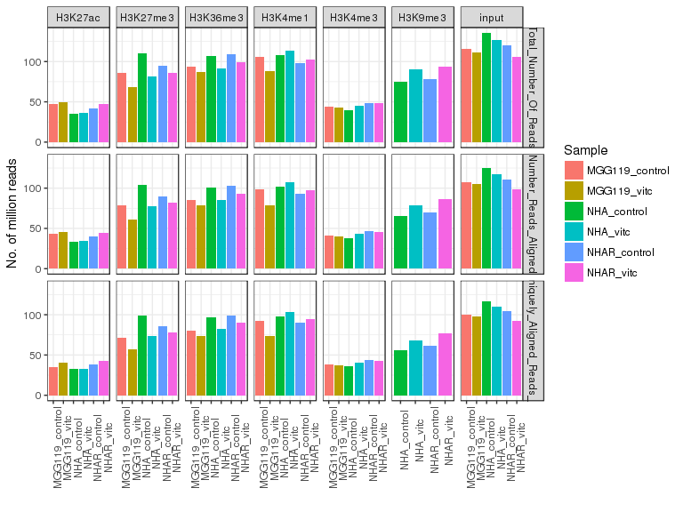

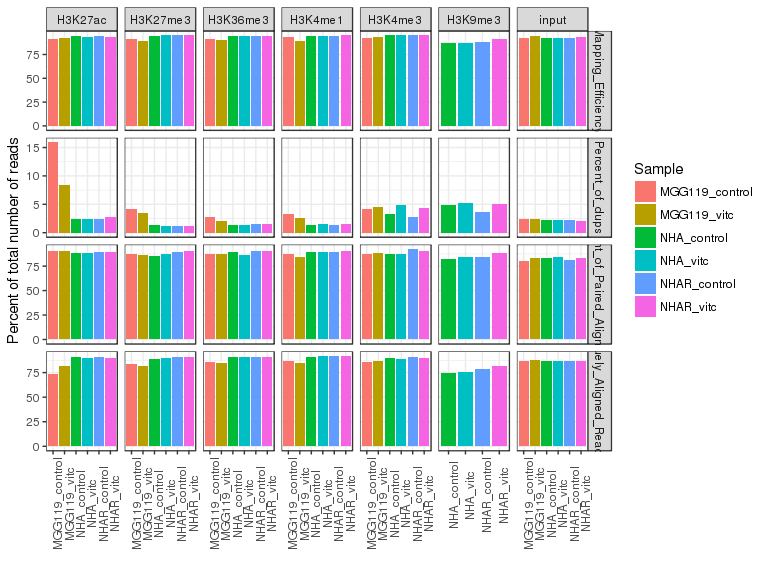

## Enrich regions

- From [UCSC tracks](http://www.bcgsc.ca/downloads/mb/VitC_glioma/HistoneHub/hub.txt), FindER results make more sense than MACS2.
- FindER2 results showed much more ERs in addition to FindER ERs. Most of the additional ERs seems real from UCSC tracks.

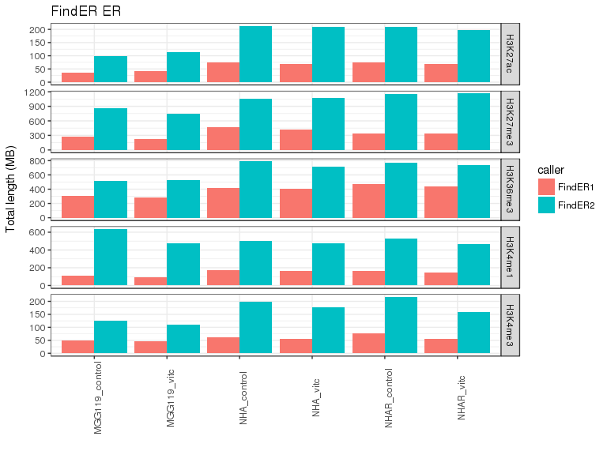

## Unique enrich regions

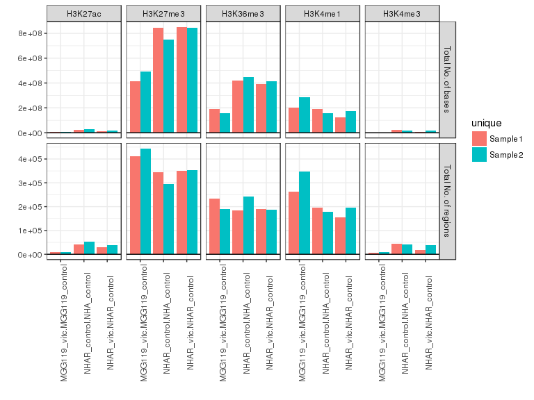

### H3K27ac homer

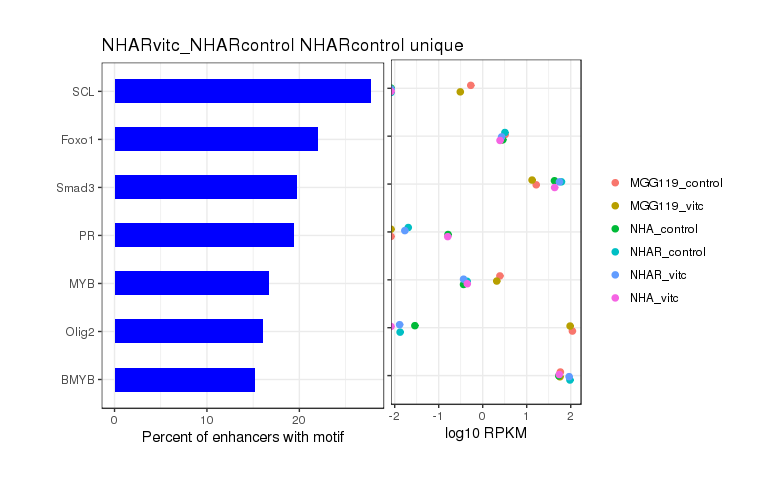

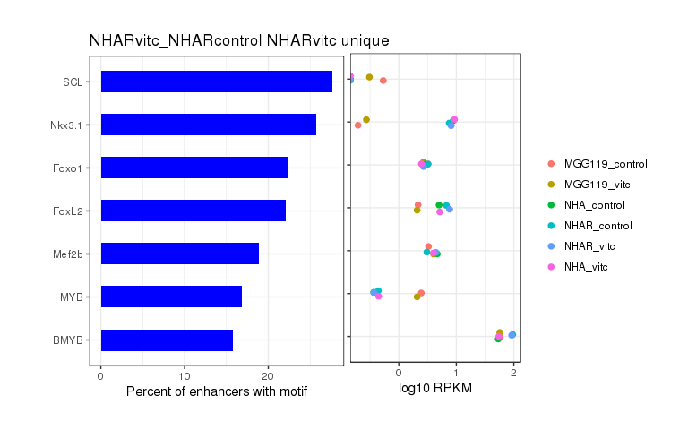

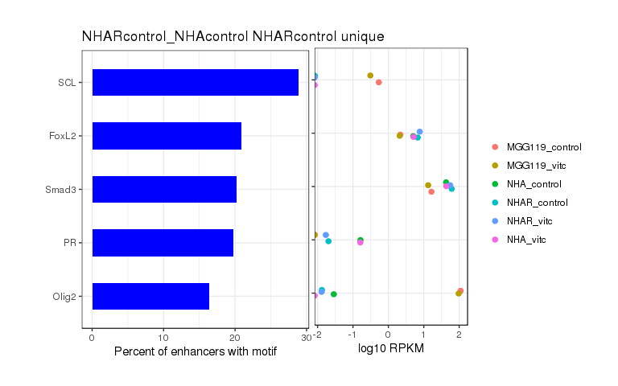

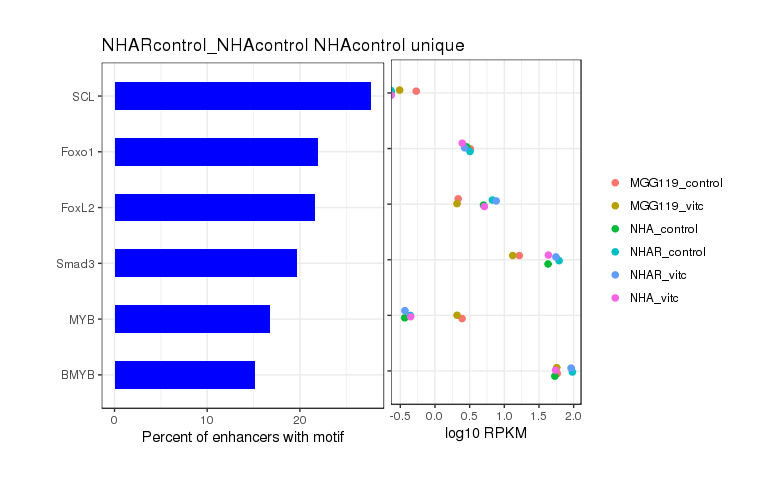

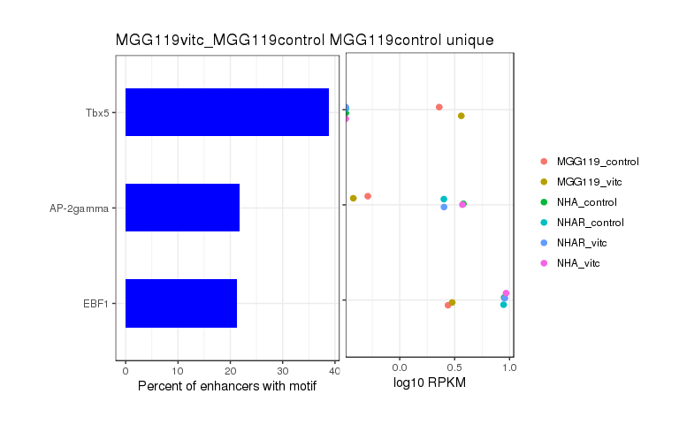

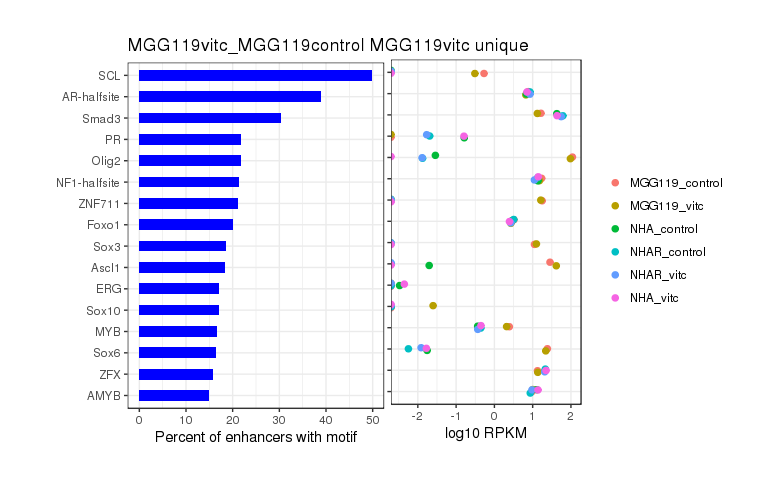

### VitC reversed histone modification regions

- mut_gain.vitc_loss: regions marked in NHAR but not in NHA overlapped with regions present in NHAR_control but not in NHAR_vitc.
- mut_loss.vitc_gain: regions marked in NHA but not in NHAR overlapped with regions present in NHAR_vitc but not in NHAR_control.

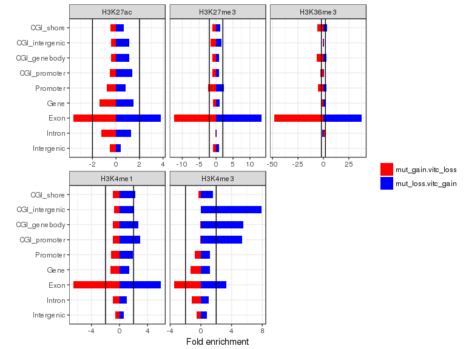

#### H3K27ac

- mut_gain.vitc_loss: 29482 regions.
- mut_loss.vitc_gain: 7099 regions.

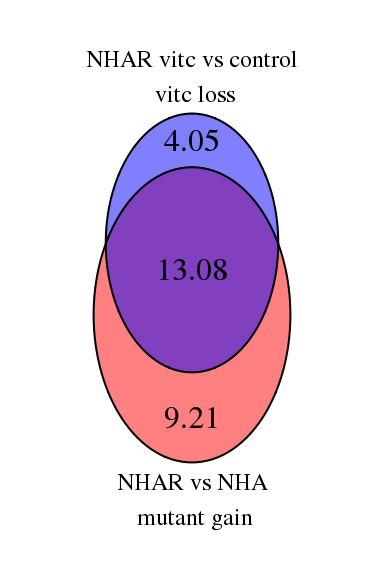

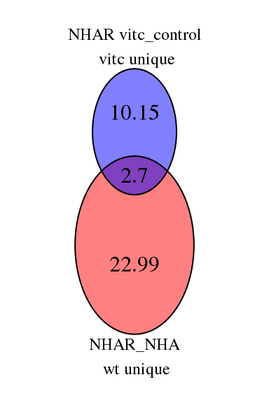

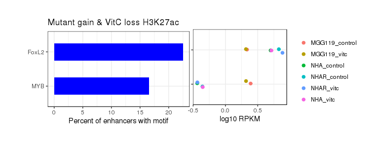

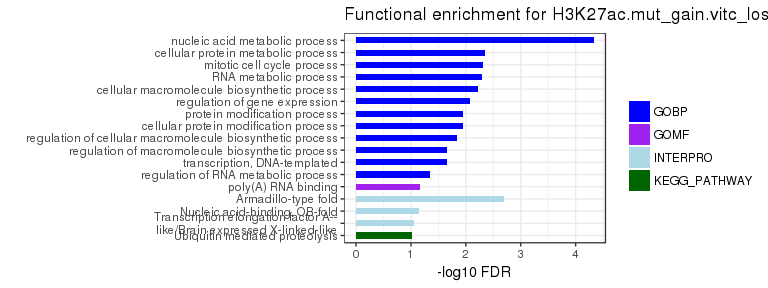

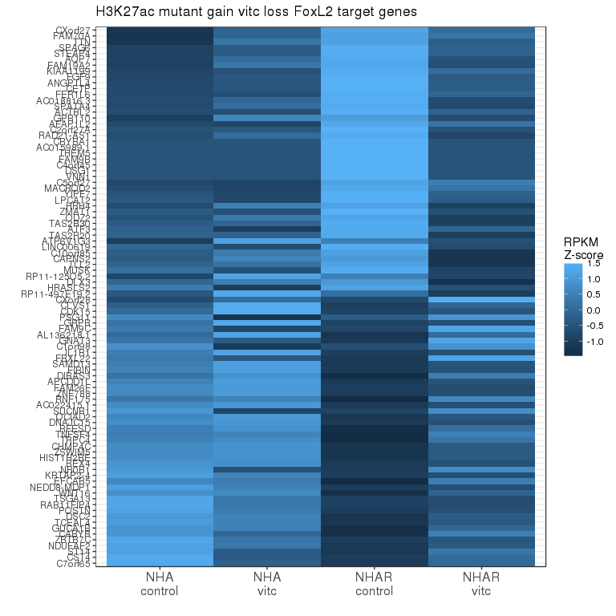

#### H3K4me1

- mut_gain.vitc_loss: 175773 regions.
- mut_loss.vitc_gain: 94757 regions.

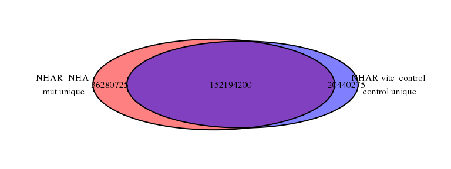

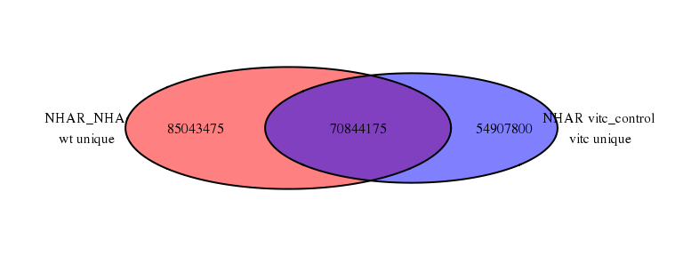

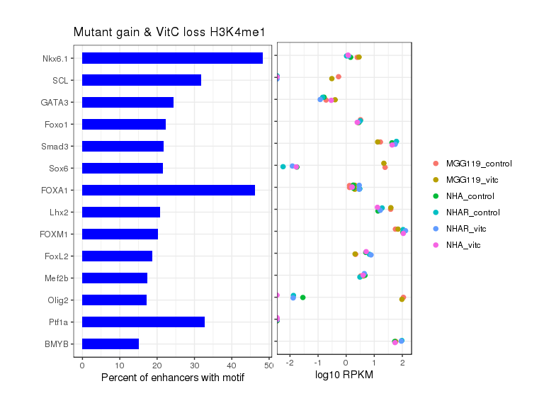

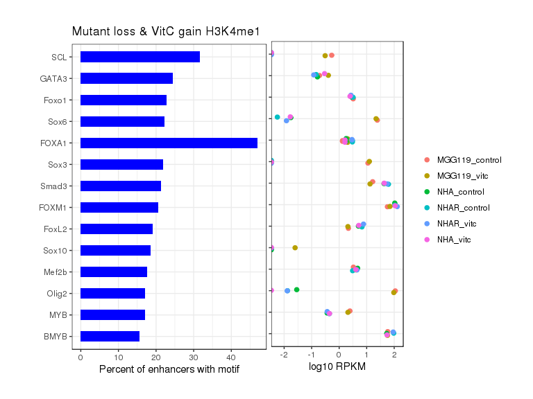

#### H3K4me3

- mut_gain.vitc_loss: 27606 regions.
- mut_loss.vitc_gain: 3892 regions.

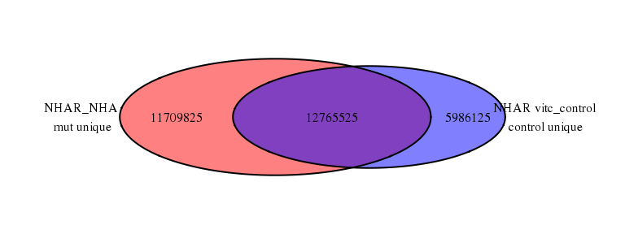

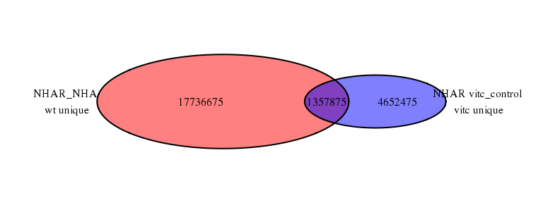

#### H3K27me3

- mut_gain.vitc_loss: 338258 regions.
- mut_loss.vitc_gain: 280807 regions.

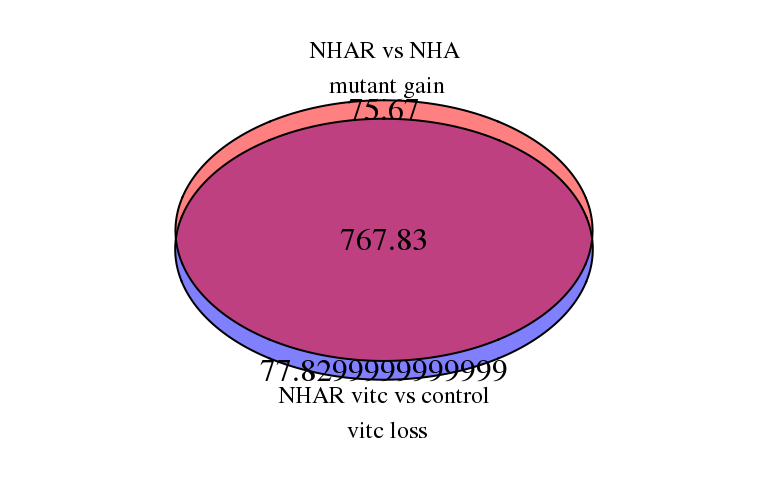

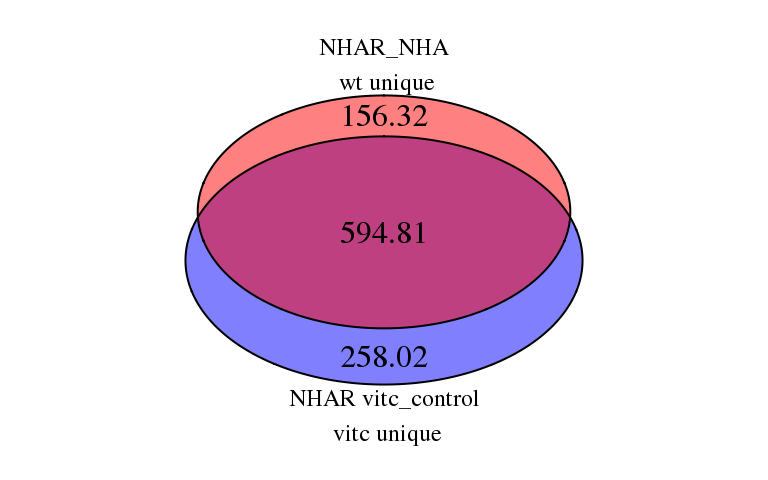

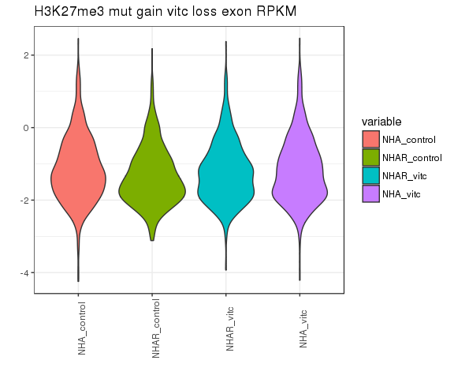

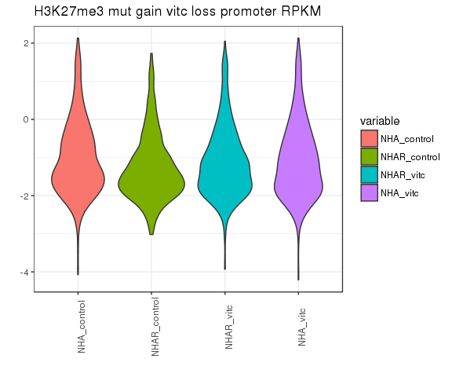

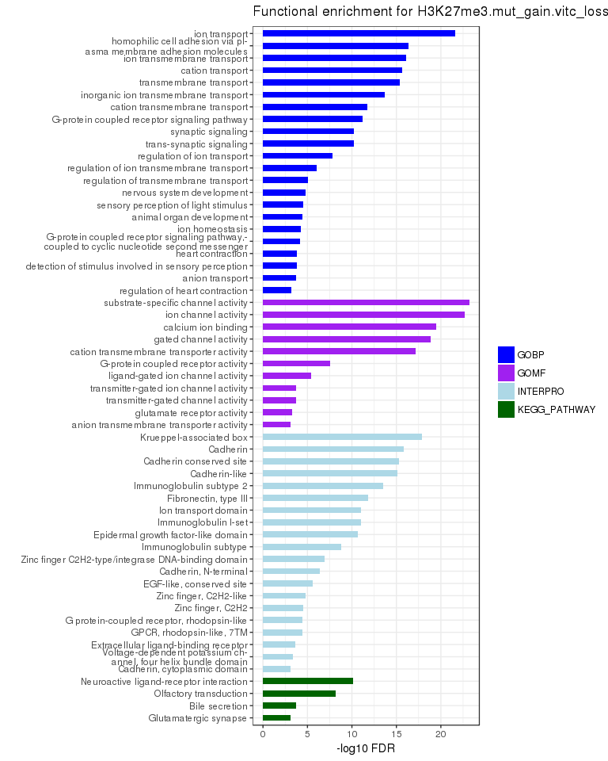

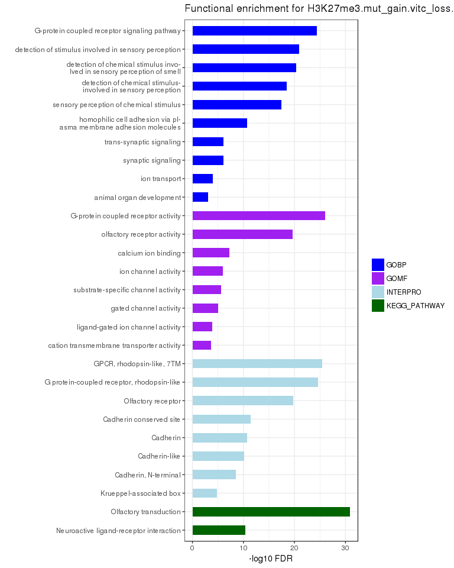

#### H3K36me3

- mut_gain.vitc_loss: 183643 regions.
- mut_loss.vitc_gain: 177902 regions.

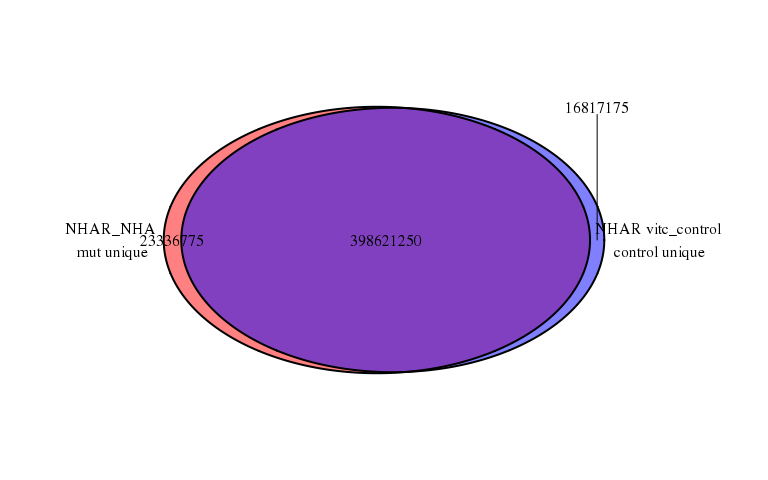

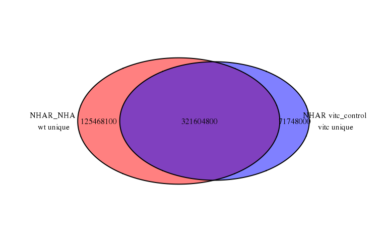

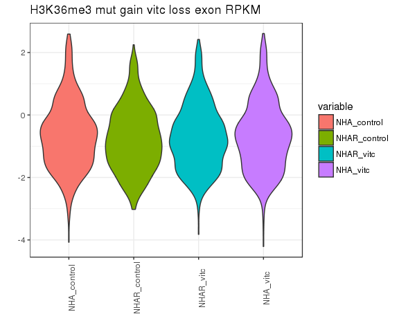

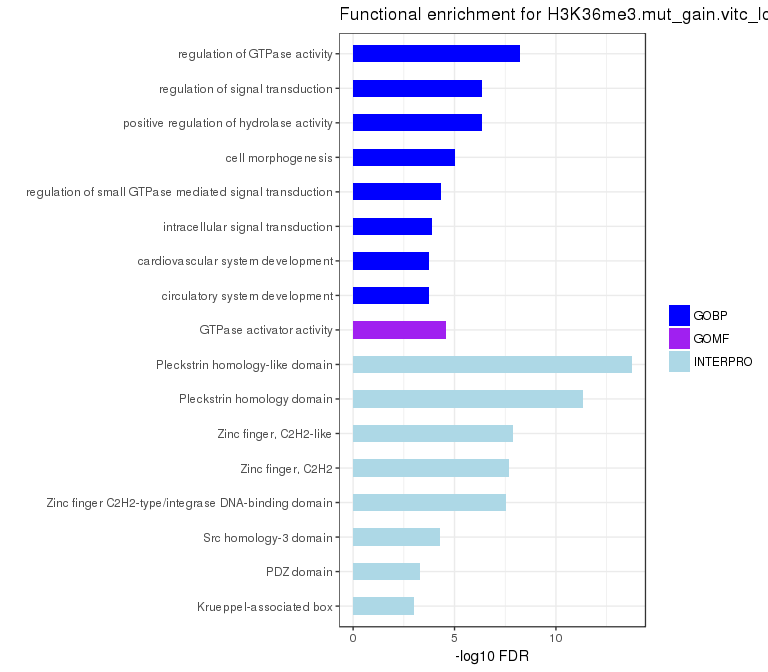